# Direction_change.Rmd

Richard Lussier & Nic McPhee

12/9/2022

## The idea

The goal is to count the number of *direction changes* in either (or both) of the `TotalError` or `NumFailedCases` columns across a given run. That will then be a measure of that run’s *stability*, with more direction changes indicating a more *unstable* run.

We might then also plot this alongside the cumulative `RanOutOfSteps`. If we’re still running out of steps everywhere, then we suspect that both the number of direction changes and the cumulative `RanOutSteps` will keep going up “together”. Maybe there’s a correlation test to be done there?

## Counting direction changes

### GCD

#### Step limit 200

```r
gcdTwoRange <- read.delim("~/R/step-limit-research/gcdTwoRange_v2.txt")
gcdTwoRange_direction_changes <- CountDirectionChangesForRun(gcdTwoRange)
```

##### Direction changes for `TotalError` for GCD, step limit 200

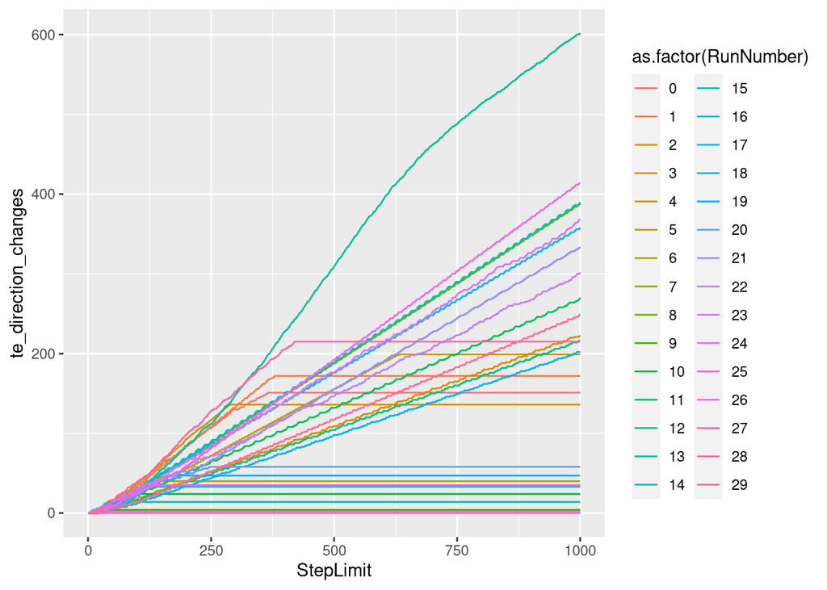

```r
ggplot(gcdTwoRange_direction_changes, aes(x=StepLimit, y=te_direction_changes, group=RunNumber, color=as.factor(RunNumber))) + geom_line()
```

Here there are something like four groups of behaviors:

- Quite a few runs flatten out pretty early (before StepLimit 250)
- A few other runs flatten out higher and later, i.e., their total error flips more and for longer
- Several runs have a steady increase in the number of direction changes across the whole range of step limits
- One is like the previous ones, but increases *much* faster than the others

The ones that flatten out probably (but we’d have to look into that) use the approach of “unrolling” the loop a given number of times, and then ending. These are never really going to generalize across *all* inputs because they have a fixed limit on how many times they can go through the “loop”.

The ones where the number of `TotalError` direction changes continues to grow probably have infinite loops and just rely on the step limit to end things. No idea what’s going on with the one that grows so fast. It needs to switch direction for almost every increment of step limit. Is that a loop with just one or two instructions?

##### Direction changes for `NumFailedCases` for GCD, step limit 200

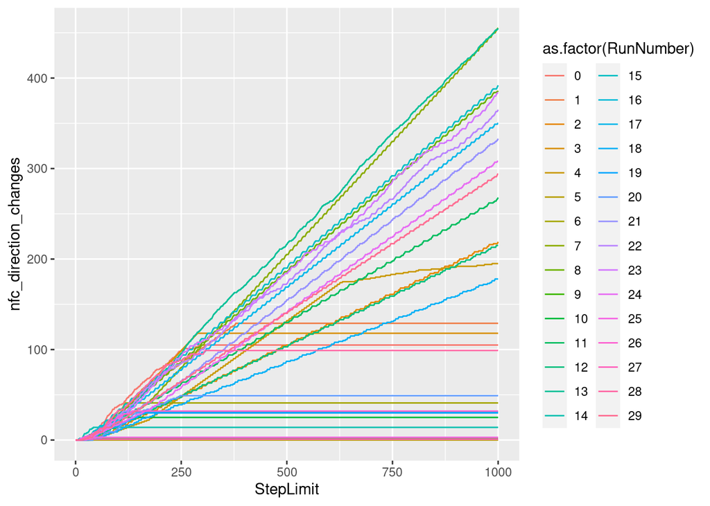

```r
ggplot(gcdTwoRange_direction_changes, aes(x=StepLimit, y=nfc_direction_changes, group=RunNumber, color=as.factor(RunNumber))) + geom_line()
```

This is pretty similar to the previous plot. There’s an interesting ochre run in the middle that has the slope of the line sharply drop at around step limit 625, but doesn’t go *flat*. Not at all sure what’s happening there.

#### Step limit 800

```r
gcdEightRange <- read.delim("~/R/step-limit-research/gcdEightRange_v2.txt")
gcdEightRange_direction_changes <- CountDirectionChangesForRun(gcdEightRange)
```

##### Direction changes for `TotalError` for GCD, step limit 800

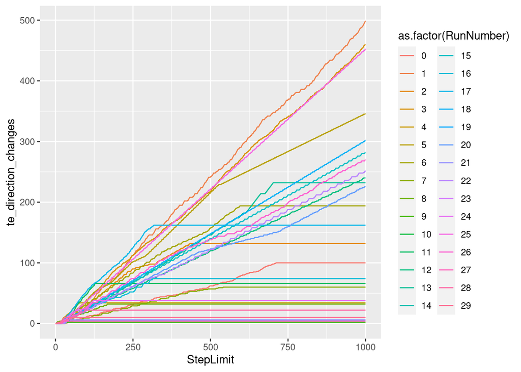

```r
ggplot(gcdEightRange_direction_changes, aes(x=StepLimit, y=te_direction_changes, group=RunNumber, color=as.factor(RunNumber))) + geom_line()
```

Structurally similar to the GCD runs with step limit 200. Some flatten out at some point, presumably because of the “loop unrolling” approach, while others increase steadily across the entire graph.

There’s again an ochre colored run that has a noticable drop in the slope at just after step limit 500; don’t know what’s happening there.

##### Direction changes for `NumFailedCases` for GCD, step limit 800

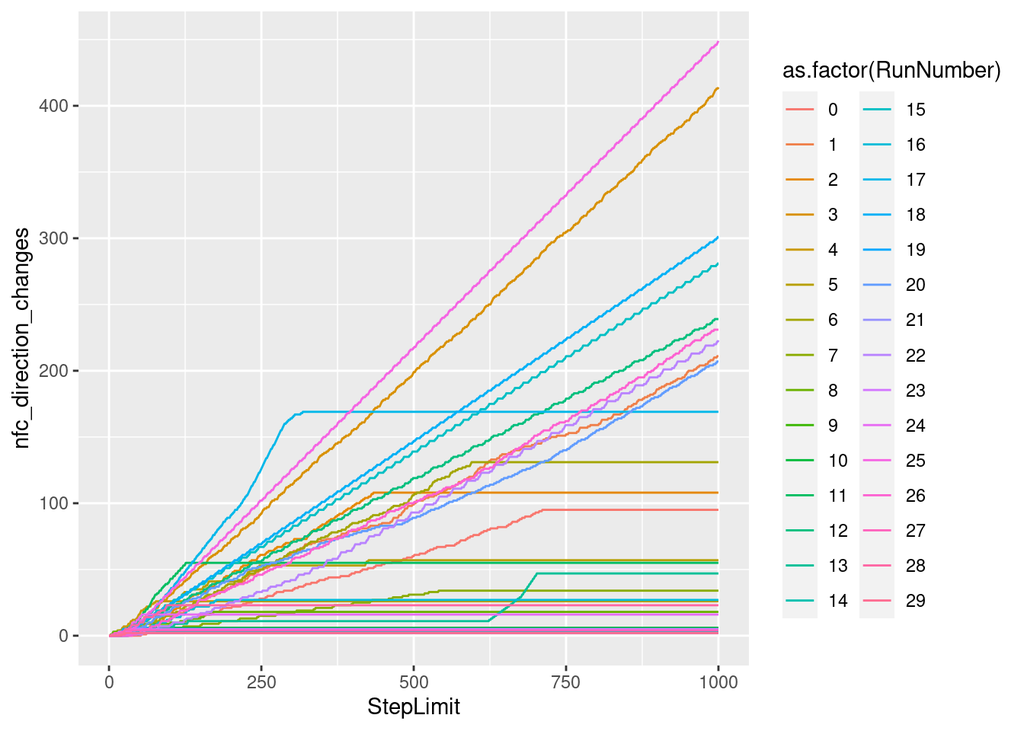

```r
ggplot(gcdEightRange_direction_changes, aes(x=StepLimit, y=nfc_direction_changes, group=RunNumber, color=as.factor(RunNumber))) + geom_line()
```

This has a couple of interesting runs:

- The light blue run that climbs steeply until shortly after step limit 250, and then goes flat.
- The green-ish-blue run that is flat and quite low until around step limit 625, then goes up pretty steeply for a little bit, and then goes flat again around step limit 700, staying flat to the end. I really have no idea what would trigger that odd change in that short phase.

## Correlating with the number of cases that run out of steps

### GCD 200

To see how various notions of stability match up with running out of steps, this computes four possible measures of overall stability:

- `te_std` is the standard deviation of the `TotalError` column for each run
- `nfc_std` is the standard deviation of `NumFailedCases` for each run
- `te_final` is the final (max) value of the number of direction changes in the `TotalError` column
- `nfc_final` is the final (max) value of the number of direction changes in the `NumFailedCases` column

This also extracts `num_ran_out`, which is the number of cases that ran out of steps at step limit 1,000.

```r
summary_stats_gcd_200 = gcdTwoRange_direction_changes %>%
    group_by(RunNumber) %>%
    summarise(te_sd = sd(TotalError, na.rm=TRUE),
              nfc_sd = sd(NumFailedCases, na.rm=TRUE),
              te_final = max(te_direction_changes, na.rm=TRUE),
              nfc_final = max(nfc_direction_changes, na.rm=TRUE),
              num_ran_out = min(RanOutOfSteps, na.rm=TRUE))
```

We can then correlate each of those four measures of stability with `num_ran_out`:

```r
cor(summary_stats_gcd_200$te_sd, summary_stats_gcd_200$num_ran_out)
```

```
## [1] 0.5714297
```

```r
cor(summary_stats_gcd_200$nfc_sd, summary_stats_gcd_200$num_ran_out)
```

```
## [1] 0.7662948
```

```r
cor(summary_stats_gcd_200$te_final, summary_stats_gcd_200$num_ran_out)
```

```
## [1] 0.8330071
```

```r
cor(summary_stats_gcd_200$nfc_final, summary_stats_gcd_200$num_ran_out)
```

```
## [1] 0.8938838
```

Based on these results, the best correlation is with `nfc_final`, i.e., the total number of direction changes in the `NumFailedCases` for a run, so we’ll probably use that moving forward.

### GCD 800

```r
summary_stats_gcd_800 = gcdEightRange_direction_changes %>%
    group_by(RunNumber) %>%
    summarise(te_sd = sd(TotalError, na.rm=TRUE),
              nfc_sd = sd(NumFailedCases, na.rm=TRUE),
              te_final = max(te_direction_changes, na.rm=TRUE),
              nfc_final = max(nfc_direction_changes, na.rm=TRUE),
              num_ran_out = min(RanOutOfSteps, na.rm=TRUE))
```

We can then correlate each of those four measures of stability with `num_ran_out`:

```r
cor(summary_stats_gcd_800$te_sd, summary_stats_gcd_800$num_ran_out)
```

```
## [1] 0.3780865
```

```r
cor(summary_stats_gcd_800$nfc_sd, summary_stats_gcd_800$num_ran_out)
```

```
## [1] 0.35412
```

```r
cor(summary_stats_gcd_800$te_final, summary_stats_gcd_800$num_ran_out)
```

```
## [1] 0.7846929
```

```r
cor(summary_stats_gcd_800$nfc_final, summary_stats_gcd_800$num_ran_out)
```

```
## [1] 0.8797872
```

### Middle Character

#### Step limit 200

```r
mcTwoRange <- read.csv("~/R/step-limit-research/MCTwoRange_v2.txt", sep="")
mcTwoRange_direction_changes <- CountDirectionChangesForRun(mcTwoRange)
```

##### Direction changes for `TotalError` for Middle Character, step limit 200

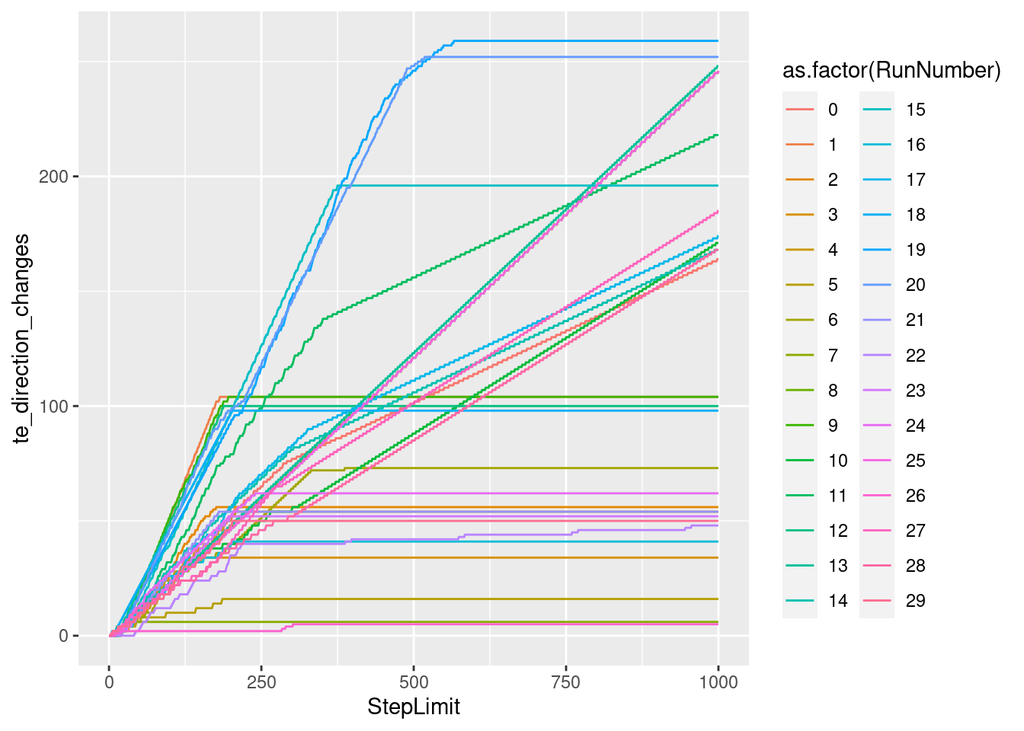

```r
ggplot(mcTwoRange_direction_changes, aes(x=StepLimit, y=te_direction_changes, group=RunNumber, color=as.factor(RunNumber))) + geom_line()
```

##### Direction changes for `NumFailedCases` for Middle Character, step limit 200

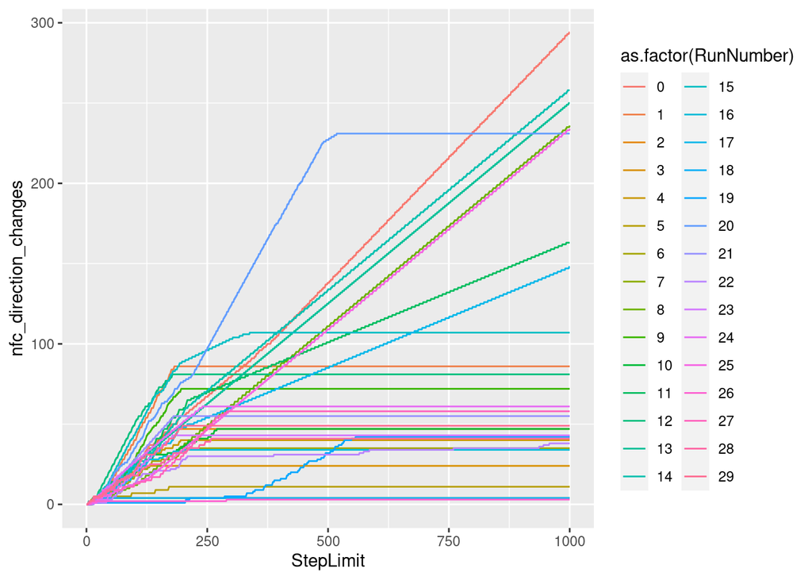

```r
ggplot(mcTwoRange_direction_changes, aes(x=StepLimit, y=nfc_direction_changes, group=RunNumber, color=as.factor(RunNumber))) + geom_line()
```

##### Correlations for Middle Character, step limit 200

```r
summary_stats_mc_200 = mcTwoRange_direction_changes %>%
    group_by(RunNumber) %>%
    summarise(te_sd = sd(TotalError, na.rm=TRUE),
              nfc_sd = sd(NumFailedCases, na.rm=TRUE),
              te_final = max(te_direction_changes, na.rm=TRUE),
              nfc_final = max(nfc_direction_changes, na.rm=TRUE),
              num_ran_out = min(RanOutOfSteps, na.rm=TRUE))
```

```r
cor(summary_stats_mc_200$te_sd, summary_stats_mc_200$num_ran_out)
```

```
## [1] -0.08568809
```

```r
cor(summary_stats_mc_200$nfc_sd, summary_stats_mc_200$num_ran_out)
```

```
## [1] 0.1923545
```

```r
cor(summary_stats_mc_200$te_final, summary_stats_mc_200$num_ran_out)
```

```
## [1] 0.3856485
```

```r
cor(summary_stats_mc_200$nfc_final, summary_stats_mc_200$num_ran_out)
```

```
## [1] 0.4322585
```

#### Step limit 400

```r
mcFourRange <- read.csv("~/R/step-limit-research/MCFourRange_v2.txt", sep="")
mcFourRange_direction_changes <- CountDirectionChangesForRun(mcFourRange)
```

##### Direction changes for `TotalError` for Middle Character, step limit 400

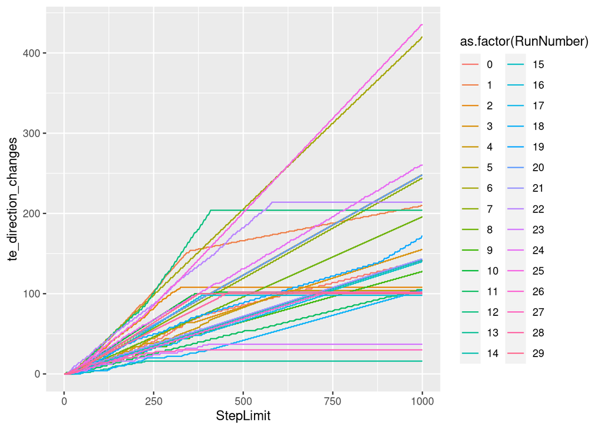

```r
ggplot(mcFourRange_direction_changes, aes(x=StepLimit, y=te_direction_changes, group=RunNumber, color=as.factor(RunNumber))) + geom_line()
```

##### Direction changes for `NumFailedCases` for Middle Character, step limit 400

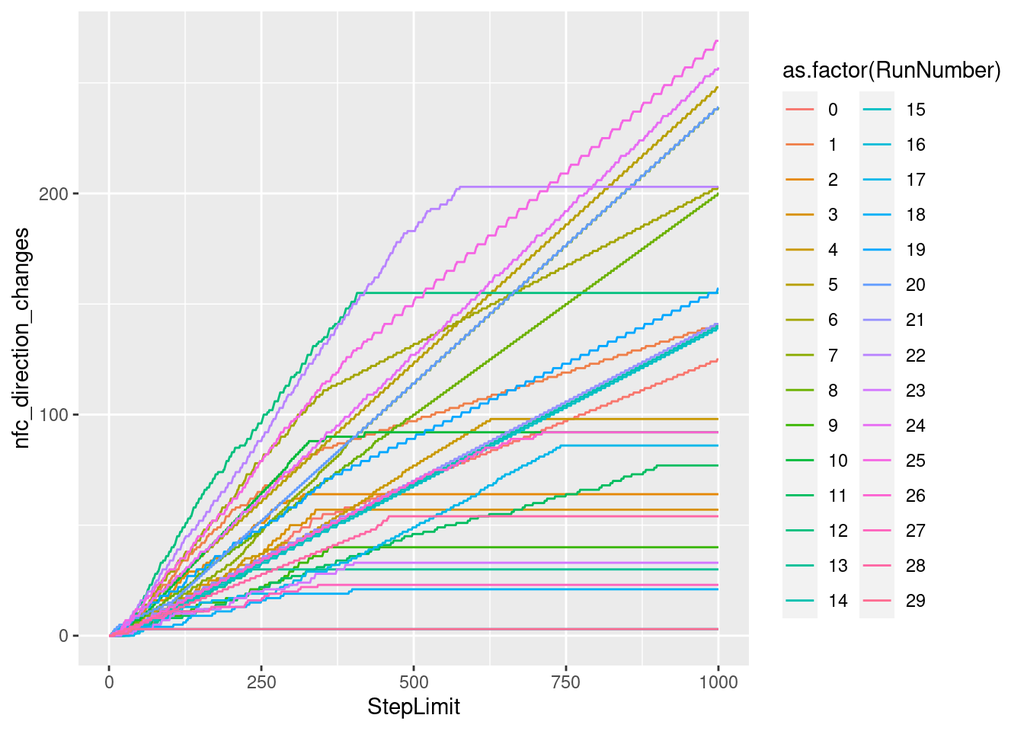

```r
ggplot(mcFourRange_direction_changes, aes(x=StepLimit, y=nfc_direction_changes, group=RunNumber, color=as.factor(RunNumber))) + geom_line()
```

##### Correlations for Middle Character, step limit 400

```r
summary_stats_mc_400 = mcFourRange_direction_changes %>%
    group_by(RunNumber) %>%
    summarise(te_sd = sd(TotalError, na.rm=TRUE),
              nfc_sd = sd(NumFailedCases, na.rm=TRUE),
              te_final = max(te_direction_changes, na.rm=TRUE),
              nfc_final = max(nfc_direction_changes, na.rm=TRUE),
              num_ran_out = min(RanOutOfSteps, na.rm=TRUE))
```

```r
cor(summary_stats_mc_400$te_sd, summary_stats_mc_400$num_ran_out)
```

```
## [1] -0.04872
```

```r
cor(summary_stats_mc_400$nfc_sd, summary_stats_mc_400$num_ran_out)
```

```
## [1] -0.04970398
```

```r
cor(summary_stats_mc_400$te_final, summary_stats_mc_400$num_ran_out)
```

```
## [1] 0.2442645
```

```r
cor(summary_stats_mc_400$nfc_final, summary_stats_mc_400$num_ran_out)
```

```
## [1] 0.1622571
```

#### Step limit 800

```r
mcEightRange <- read.csv("~/R/step-limit-research/MCEightRange_v2.txt", sep="")
mcEightRange_direction_changes <- CountDirectionChangesForRun(mcEightRange)
```

##### Direction changes for `TotalError` for Middle Character, step limit 800

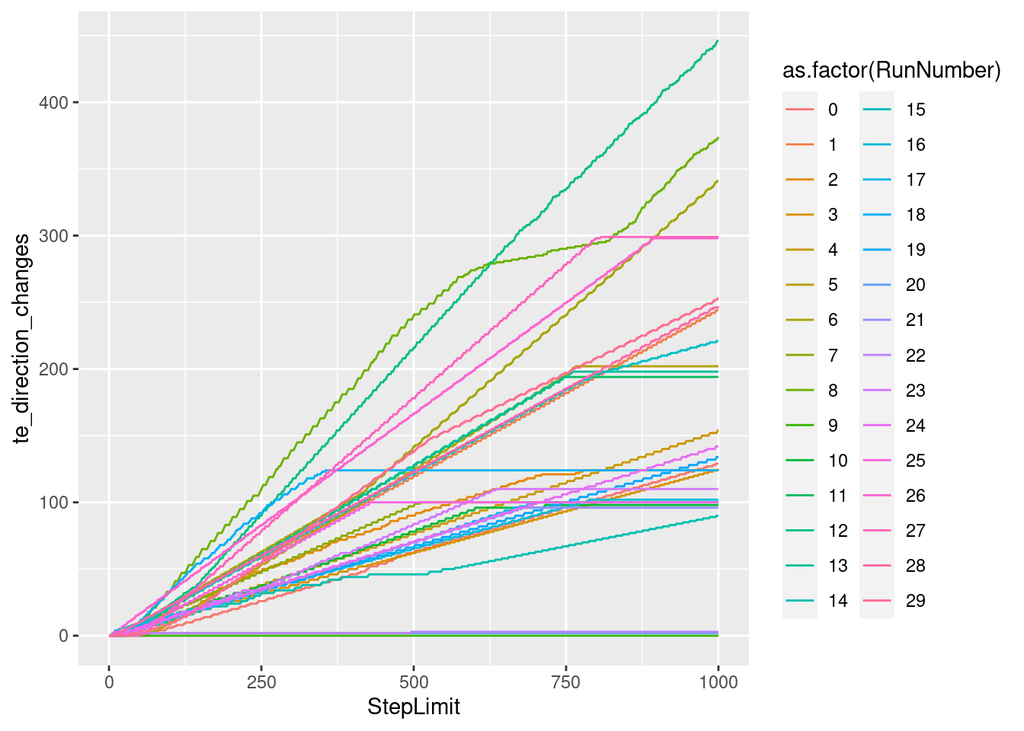

```r
ggplot(mcEightRange_direction_changes, aes(x=StepLimit, y=te_direction_changes, group=RunNumber, color=as.factor(RunNumber))) + geom_line()
```

##### Direction changes for `NumFailedCases` for Middle Character, step limit 800

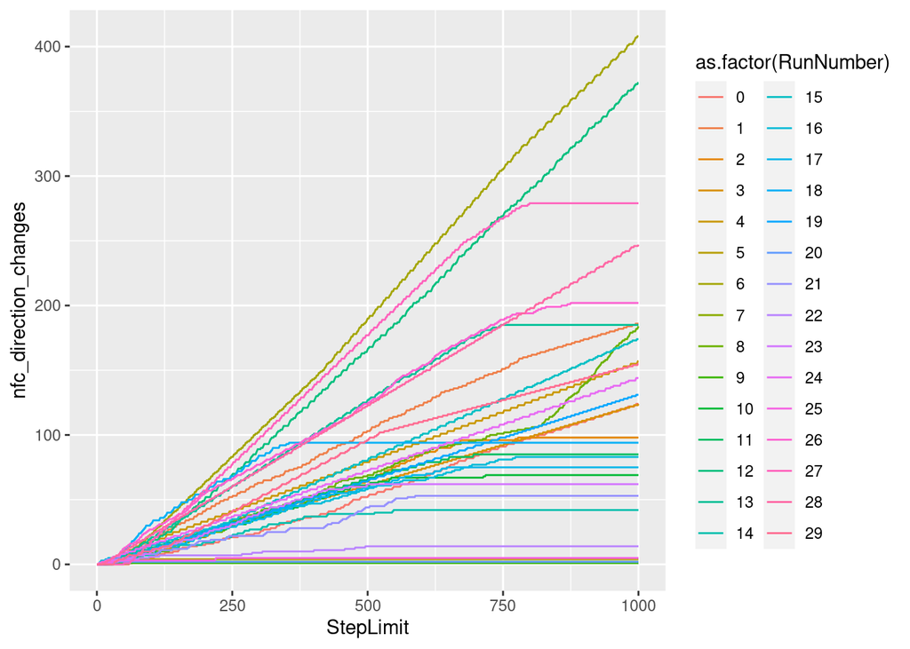

```r
ggplot(mcEightRange_direction_changes, aes(x=StepLimit, y=nfc_direction_changes, group=RunNumber, color=as.factor(RunNumber))) + geom_line()
```

##### Correlations for Middle Character, step limit 800

```r
summary_stats_mc_800 = mcEightRange_direction_changes %>%
    group_by(RunNumber) %>%
    summarise(te_sd = sd(TotalError, na.rm=TRUE),
              nfc_sd = sd(NumFailedCases, na.rm=TRUE),
              te_final = max(te_direction_changes, na.rm=TRUE),
              nfc_final = max(nfc_direction_changes, na.rm=TRUE),
              num_ran_out = min(RanOutOfSteps, na.rm=TRUE))
```

```r
cor(summary_stats_mc_800$te_sd, summary_stats_mc_800$num_ran_out)
```

```
## [1] 0.1173723
```

```r
cor(summary_stats_mc_800$nfc_sd, summary_stats_mc_800$num_ran_out)
```

```
## [1] -0.1948619
```

```r
cor(summary_stats_mc_800$te_final, summary_stats_mc_800$num_ran_out)
```

```
## [1] 0.1434412
```

```r
cor(summary_stats_mc_800$nfc_final, summary_stats_mc_800$num_ran_out)
```

```
## [1] 0.1143277
```

### Last Index of Zero

#### Step limit 200

```r
liozTwoRange <- read.csv("~/R/step-limit-research/LIOZTwoRange_v2.txt", sep="")
liozTwoRange_direction_changes <- CountDirectionChangesForRun(liozTwoRange)
```

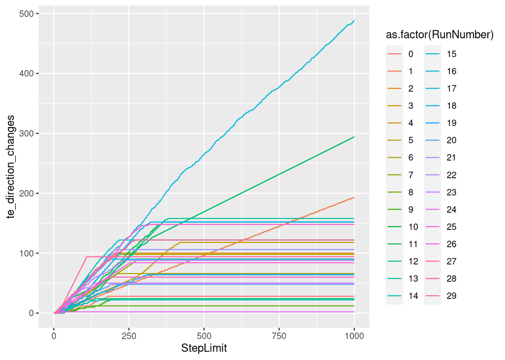

```r
ggplot(liozTwoRange_direction_changes, aes(x=StepLimit, y=te_direction_changes, group=RunNumber, color=as.factor(RunNumber))) + geom_line()
```

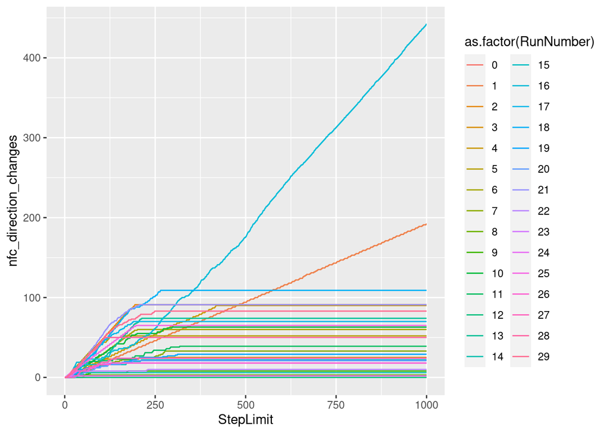

```r
ggplot(liozTwoRange_direction_changes, aes(x=StepLimit, y=nfc_direction_changes, group=RunNumber, color=as.factor(RunNumber))) + geom_line()
```

```r
summary_stats_lioz_200 = liozTwoRange_direction_changes %>%
    group_by(RunNumber) %>%
    summarise(te_sd = sd(TotalError, na.rm=TRUE),
              nfc_sd = sd(NumFailedCases, na.rm=TRUE),
              te_final = max(te_direction_changes, na.rm=TRUE),
              nfc_final = max(nfc_direction_changes, na.rm=TRUE),
              num_ran_out = min(RanOutOfSteps, na.rm=TRUE))
```

```r
cor(summary_stats_lioz_200$te_sd, summary_stats_lioz_200$num_ran_out)
```

```
## [1] -0.04645516
```

```r
cor(summary_stats_lioz_200$nfc_sd, summary_stats_lioz_200$num_ran_out)
```

```
## [1] -0.3032395
```

```r
cor(summary_stats_lioz_200$te_final, summary_stats_lioz_200$num_ran_out)
```

```
## [1] 0.7897046
```

```r
cor(summary_stats_lioz_200$nfc_final, summary_stats_lioz_200$num_ran_out)
```

```
## [1] 0.922644
```

#### Step limit 800

```r
liozEightRange <- read.csv("~/R/step-limit-research/LIOZEightRange_v2.txt", sep="")
liozEightRange_direction_changes <- CountDirectionChangesForRun(liozEightRange)
```

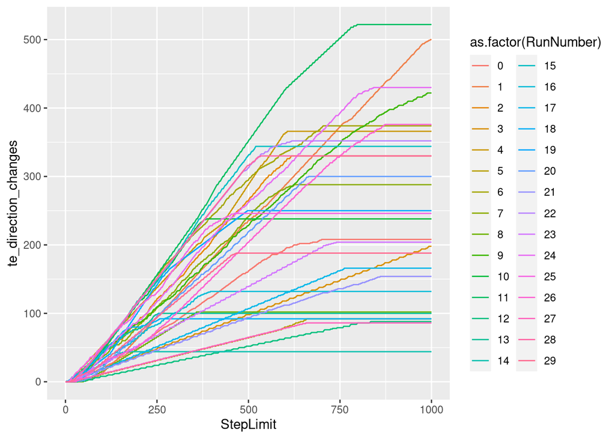

```r
ggplot(liozEightRange_direction_changes, aes(x=StepLimit, y=te_direction_changes, group=RunNumber, color=as.factor(RunNumber))) + geom_line()
```

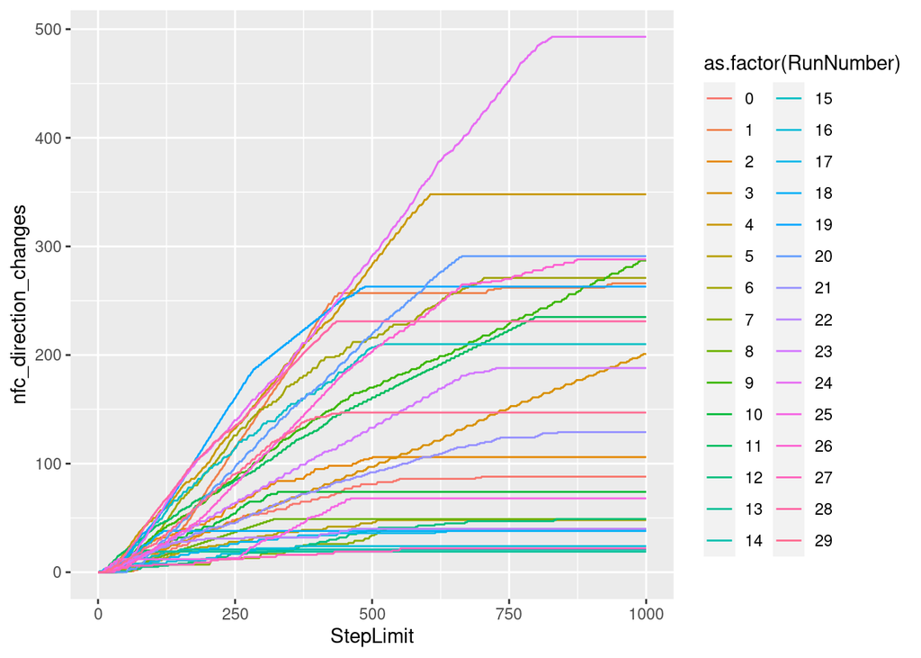

```r
ggplot(liozEightRange_direction_changes, aes(x=StepLimit, y=nfc_direction_changes, group=RunNumber, color=as.factor(RunNumber))) + geom_line()
```

```r
summary_stats_lioz_800 = liozEightRange_direction_changes %>%
    group_by(RunNumber) %>%
    summarise(te_sd = sd(TotalError, na.rm=TRUE),
              nfc_sd = sd(NumFailedCases, na.rm=TRUE),
              te_final = max(te_direction_changes, na.rm=TRUE),
              nfc_final = max(nfc_direction_changes, na.rm=TRUE),
              num_ran_out = min(RanOutOfSteps, na.rm=TRUE))
```

```r
cor(summary_stats_lioz_800$te_sd, summary_stats_lioz_800$num_ran_out)
```

```
## [1] 0.2976413
```

```r
cor(summary_stats_lioz_800$nfc_sd, summary_stats_lioz_800$num_ran_out)
```

```
## [1] 0.1033169
```

```r
cor(summary_stats_lioz_800$te_final, summary_stats_lioz_800$num_ran_out)
```

```
## [1] 0.1945998
```

```r
cor(summary_stats_lioz_800$nfc_final, summary_stats_lioz_800$num_ran_out)
```

```
## [1] 0.07633258
```